# Clase_8_ST

Javier López

14/5/2020

### **Modelo VEC**

Siguiendo el artículo “Propuesta de un índice SIPSA y su relación con la inflación de alimentos para el caso colombiano: evidencia empírica” de Lozano y Santana, definimos los modelos de Vectores de Corrección de Errores *(VEC)*, son modelos *VAR* restringidos que dentro de su especificación incluyen las relaciones de cointegración, es decir, su aplicación está centrada en series no estacionarias cointegradas, que guardan relaciones a largo plazo entre ellas.
Considerando el modelo *VAR(p)*,
$$\mathbf{y_t}=A_1\mathbf{y_{t-1}}+...+A_p\mathbf{y_{t-p}}+\epsilon_t$$
Se define el modelo de corrección de errores como:
$$\Delta \mathbf{y_t} = \alpha \beta^´\mathbf{y_{t-p}} + \Gamma_1 \Delta \mathbf{y_{t-1}} + ...+ \Gamma_{p-1} \Delta \mathbf{y_{t-p+1}} + \mathbf{u_t},$$
donde
$$\Gamma_i = -(I-A_1-...-A_i), \;\;\ i = 1,...,p-1$$
y
$$\alpha \beta^´= \Gamma = -(I-A_1-...-A_p)$$
Las matrices $\Gamma_i$ contienen los impactos acumulados de largo plazo. Es así que la especificación del *VEC* es sinónimo de una relación a largo plazo.

### Ejemplo de simulación

Simulamos un sistema de 3 variables con relación de cointegración.

```r
library(urca)
```

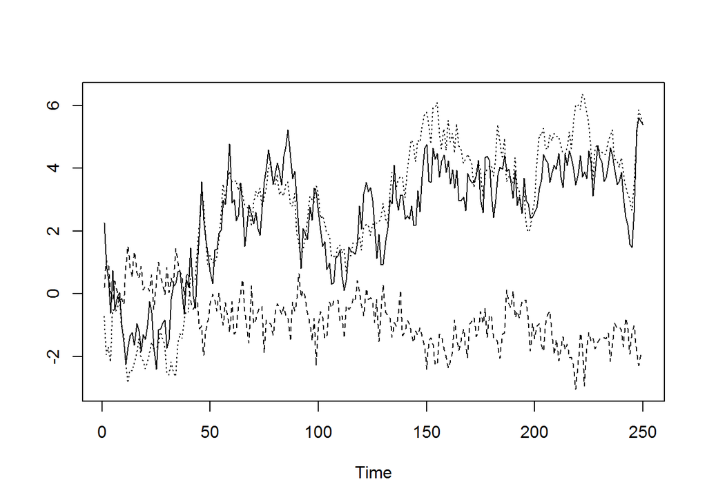

```r
set.seed(12345)
e1 <- rnorm(250, 0, 0.5)
e2 <- rnorm(250, 0, 0.5)
e3 <- rnorm(250, 0, 0.5)
u1.ar1 <- arima.sim(model = list(ar = 0.75),
                    innov = e1, n = 250)
u2.ar1 <- arima.sim(model = list(ar = 0.3),
                    innov = e2, n = 250)
y3 <- cumsum(e3)
y1 <- 0.8 * y3 + u1.ar1
y2 <- -0.3 * y3 + u2.ar1
ts.plot(y1, y2, y3, lty = c(1:3))
```

```r
y.mat <- data.frame(y1, y2, y3)
vecm  <- ca.jo(y.mat)
jo.results <- summary(vecm)
jo.results
```

```
##
## ######################
## # Johansen-Procedure #
## ######################
##
## Test type: maximal eigenvalue statistic (lambda max) , with linear trend
##
## Eigenvalues (lambda):
## [1] 0.27036254 0.15474942 0.01884032
##
## Values of teststatistic and critical values of test:
##
##           test 10pct  5pct  1pct
## r <= 2 |  4.72  6.50  8.18 11.65
## r <= 1 | 41.69 12.91 14.90 19.19
## r = 0  | 78.17 18.90 21.07 25.75
##
## Eigenvectors, normalised to first column:
## (These are the cointegration relations)
##
##           y1.l2      y2.l2     y3.l2
## y1.l2  1.000000  1.0000000 1.0000000
## y2.l2 -4.732436  0.2273774 0.1513858
## y3.l2 -2.129850 -0.6657324 2.3153224
##
## Weights W:
## (This is the loading matrix)
##
##             y1.l2       y2.l2        y3.l2
## y1.d -0.034235501 -0.29705774 -0.008294582
## y2.d  0.145988517 -0.08137695  0.003335110
## y3.d  0.002429191  0.01025326 -0.010523045
```

La hipotesis de conitegración de dos vectores no puede ser rechazada niveles de significancia de 10pct.

```r
vecm.r2    <- cajorls(vecm, r = 2)
vecm.r2
```

```
## $rlm
##
## Call:
## lm(formula = substitute(form1), data = data.mat)
##
## Coefficients:
##           y1.d       y2.d       y3.d
## ect1      -0.331293   0.064612   0.012682
## ect2       0.094473  -0.709385  -0.009165
## constant   0.168371  -0.027019   0.025255
## y1.dl1    -0.227677   0.027012   0.068158
## y2.dl1     0.144452  -0.715607   0.040487
## y3.dl1     0.123467  -0.290828  -0.075251
##
##
## $beta
##             ect1      ect2
## y1.l2  1.0000000 0.0000000
## y2.l2  0.0000000 1.0000000
## y3.l2 -0.7328534 0.2951962
```

La salida **$beta** hace referencia a la estimación de los vectores de cointegración normalizados para la primera variable, utilizado usualmente en econometria. La salida **$rlm** hace referencia a la estimación del modelo *VEC* de rango de cointegración $r=2$.

El modelo *VEC* se puede ver como un *VAR*, utilizamos la función *vec2var()*.

```r
library(vars)
```

```r
# Estimación
vecm.level <- vec2var(vecm , r = 2)
vecm.level
```

```
##
## Coefficient matrix of lagged endogenous variables:
##
## A1:
##         y1.l1      y2.l1      y3.l1
## y1 0.77232286 0.14445173  0.1234669
## y2 0.02701223 0.28439273 -0.2908284
## y3 0.06815811 0.04048737  0.9247494
##
##
## A2:
##          y1.l2        y2.l2      y3.l2
## y1 -0.10361609 -0.049978651 0.14721057
## y2  0.03759934  0.006222713 0.03407002
## y3 -0.05547566 -0.049652006 0.06325084
##
##
## Coefficient matrix of deterministic regressor(s).
##
##       constant
## y1  0.16837095
## y2 -0.02701889
## y3  0.02525518
```

```r
#Diagnóstico
serial.test(vecm.level)
```

```
##
##  Portmanteau Test (asymptotic)
##
## data:  Residuals of VAR object vecm.level
## Chi-squared = 120.92, df = 129, p-value = 0.6817
```

```r
arch.test(vecm.level)
```

```
##
##  ARCH (multivariate)
##
## data:  Residuals of VAR object vecm.level
## Chi-squared = 173.46, df = 180, p-value = 0.6231
```

```r
norm.test <- normality.test(vecm.level)
norm.test
```

```
## $JB
##
##  JB-Test (multivariate)
##
## data:  Residuals of VAR object vecm.level
## Chi-squared = 9.1317, df = 6, p-value = 0.1663
##
##
## $Skewness
##
##  Skewness only (multivariate)
##
## data:  Residuals of VAR object vecm.level
## Chi-squared = 5.8516, df = 3, p-value = 0.1191
##
##
## $Kurtosis
##
##  Kurtosis only (multivariate)
##
## data:  Residuals of VAR object vecm.level
## Chi-squared = 3.2801, df = 3, p-value = 0.3504
```

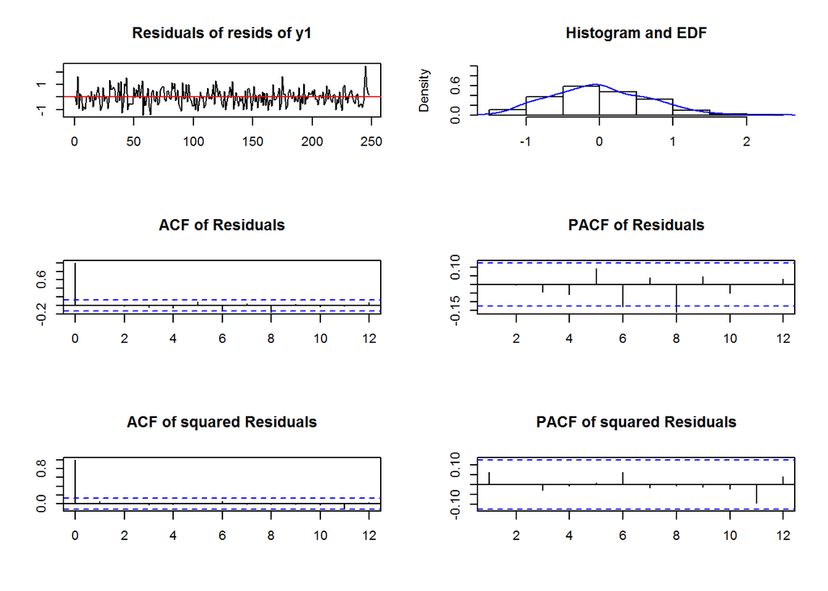

```r
plot(norm.test, names = 'resids of y1')
```

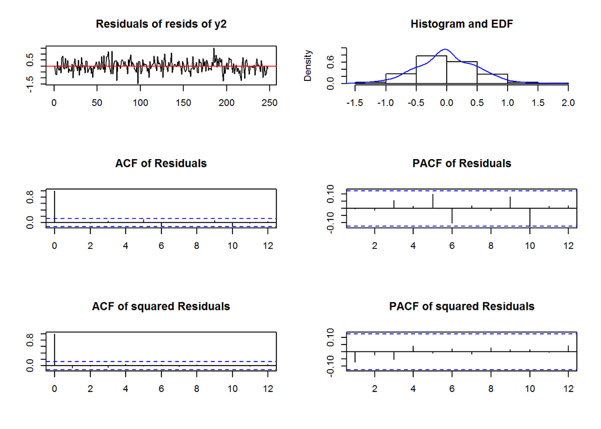

```r
plot(norm.test, names = 'resids of y2')
```

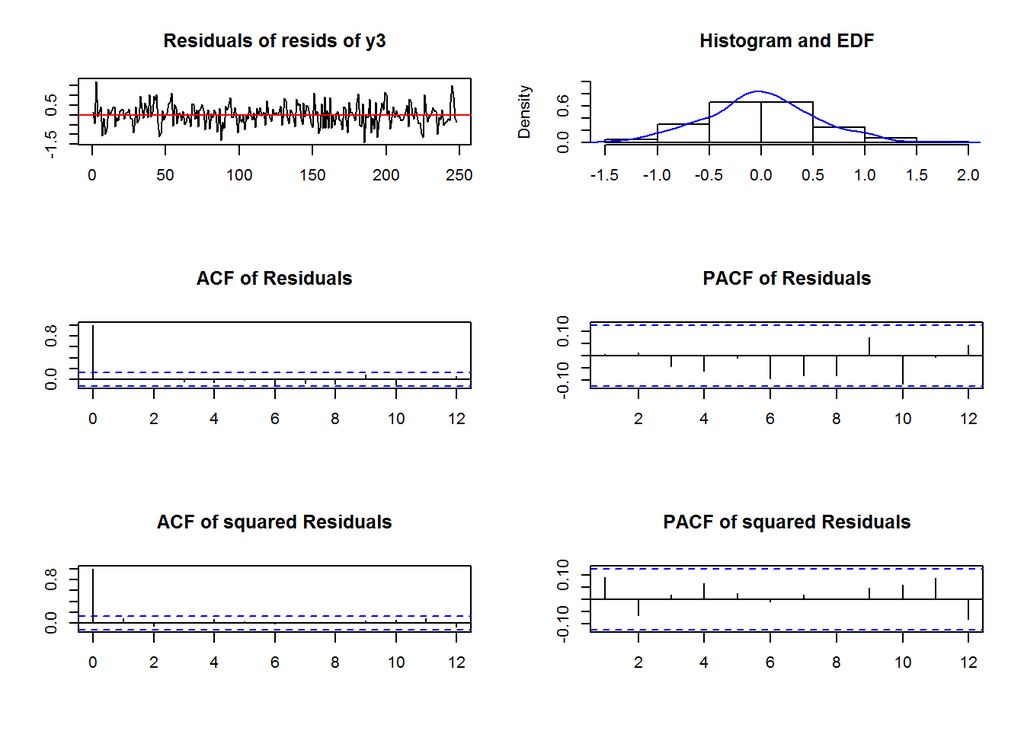

```r
plot(norm.test, names = 'resids of y3')
```

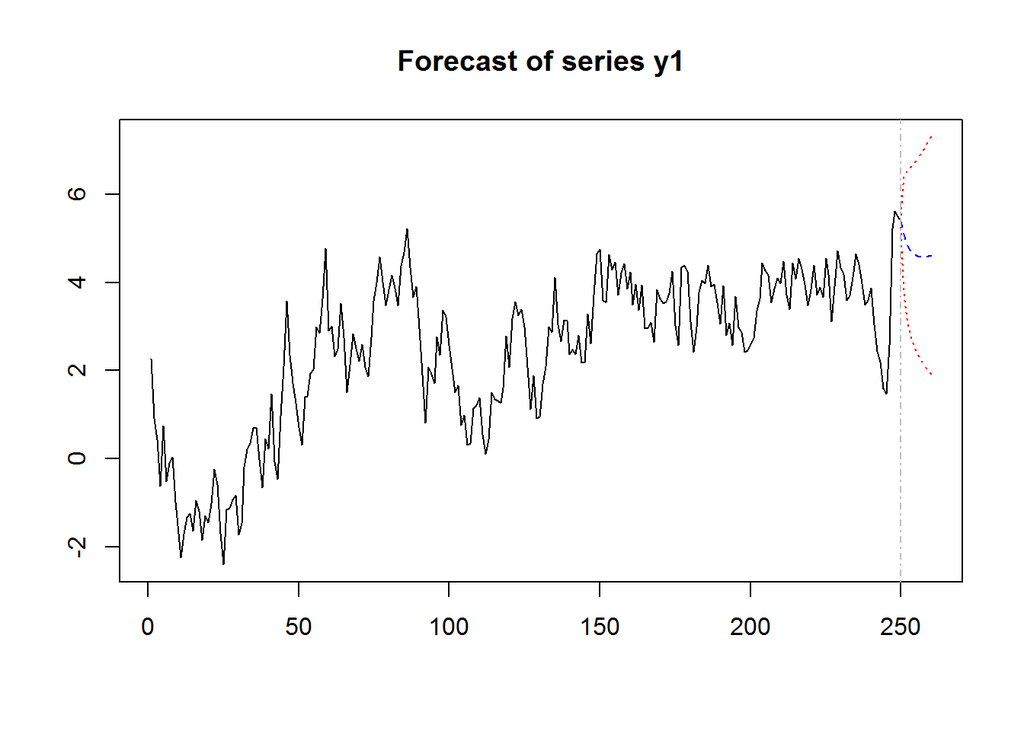

```r
#Pronóstico
predictions <- predict(vecm.level)
plot(predictions, names = 'y1')
```

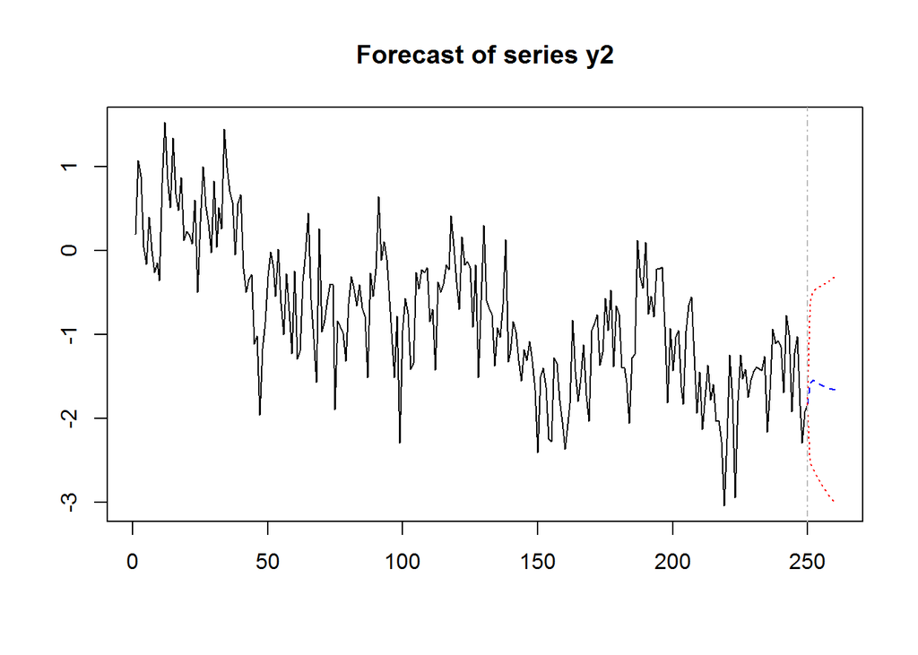

```r
plot(predictions, names = 'y2')
```

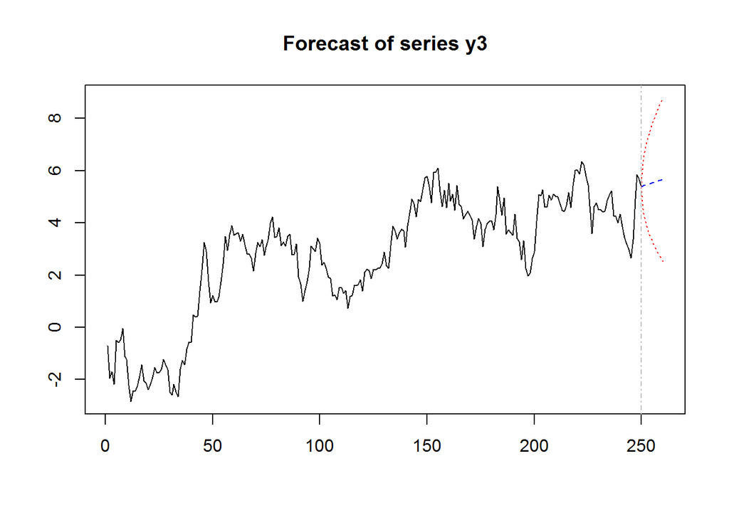

```r
plot(predictions, names = 'y3')
```

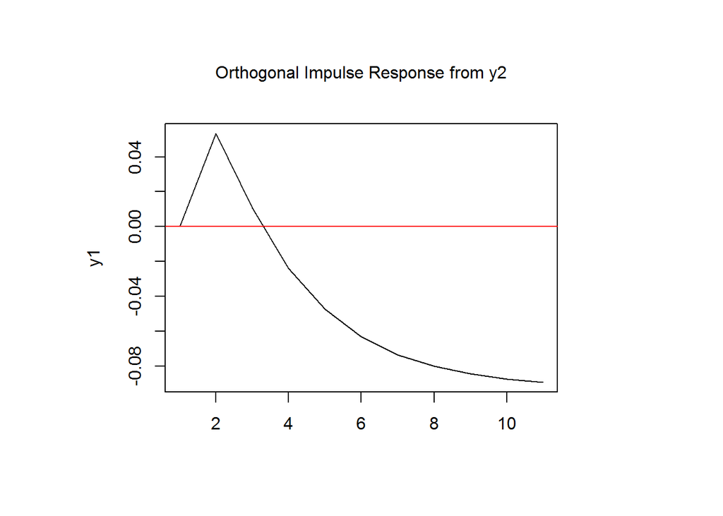

```r
# Funciones de impulso y desc. varianza
f.impu <- irf(vecm.level, impulse = 'y2',
              response = 'y1', cumulative = FALSE,
              boot = FALSE, seed = 12345)
plot(f.impu)
```

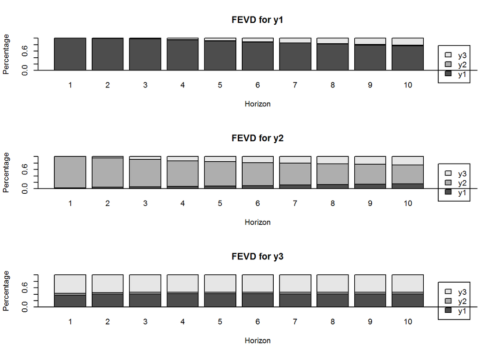

```r
var.desc <- fevd(vecm.level)
plot(var.desc, addbars = 1)
```

### Ejemplo Canada

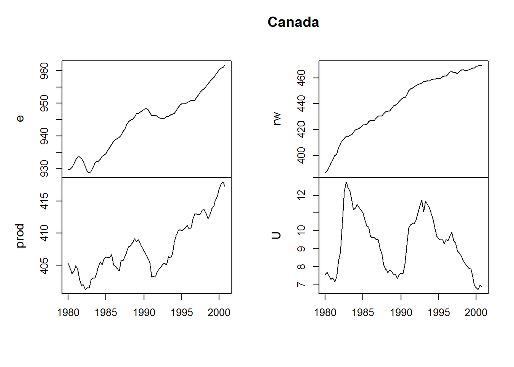

```r
library("vars")
data("Canada")
plot(Canada, nc = 2, xlab = "")
```

```r
### Especificación del modelo
VARselect(Canada, lag.max = 8, type = "both")
```

```
## $selection
## AIC(n)  HQ(n)  SC(n) FPE(n)
##      3      2      1      3
##
## $criteria
##                   1            2            3            4            5
## AIC(n) -6.272579064 -6.636669705 -6.771176872 -6.634609210 -6.398132246
## HQ(n)  -5.978429449 -6.146420347 -6.084827770 -5.752160366 -5.319583658
## SC(n)  -5.536558009 -5.409967947 -5.053794411 -4.426546046 -3.699388378
## FPE(n)  0.001889842  0.001319462  0.001166019  0.001363175  0.001782055
##                   6            7           8
## AIC(n) -6.307704843 -6.070727259 -6.06159685
## HQ(n)  -5.033056512 -4.599979185 -4.39474903
## SC(n)  -3.118280272 -2.390621985 -1.89081087
## FPE(n)  0.002044202  0.002768551  0.00306012
```

```r
Canada <- Canada[, c("prod", "e", "U", "rw")]
```

Analizando los criterios de información se pueden plantear 3 escenarios *VAR(1), VAR(2), VAR(3)*.

#### Escenario 1: VAR(1)

```r
### Estimación
p1ct   <- VAR(Canada, p = 1, type = "both")
p1ct
```

```
##
## VAR Estimation Results:
## =======================
##
## Estimated coefficients for equation prod:
## =========================================
## Call:
## prod = prod.l1 + e.l1 + U.l1 + rw.l1 + const + trend
##
##     prod.l1        e.l1        U.l1       rw.l1       const       trend
##  0.96313671  0.01291155  0.21108918 -0.03909399 16.24340747  0.04613085
##
##
## Estimated coefficients for equation e:
## ======================================
## Call:
## e = prod.l1 + e.l1 + U.l1 + rw.l1 + const + trend
##
##       prod.l1          e.l1          U.l1         rw.l1         const
##    0.19465028    1.23892283    0.62301475   -0.06776277 -278.76121138
##         trend
##   -0.04066045
##
##
## Estimated coefficients for equation U:
## ======================================
## Call:
## U = prod.l1 + e.l1 + U.l1 + rw.l1 + const + trend
##
##      prod.l1         e.l1         U.l1        rw.l1        const
##  -0.12319201  -0.24844234   0.39158002   0.06580819 259.98200967
##        trend
##   0.03451663
##
##
## Estimated coefficients for equation rw:
## =======================================
## Call:
## rw = prod.l1 + e.l1 + U.l1 + rw.l1 + const + trend
##
##      prod.l1         e.l1         U.l1        rw.l1        const
##  -0.22308744  -0.05104397  -0.36863956   0.94890946 163.02453066
##        trend
##   0.07142229
```

```r
### Diagnóstico
ser11 <- serial.test(p1ct, lags.pt = 16, type = "PT.asymptotic")
ser11$serial
```

```
##
##  Portmanteau Test (asymptotic)
##
## data:  Residuals of VAR object p1ct
## Chi-squared = 233.5, df = 240, p-value = 0.606
```

```r
arch1 <- arch.test(p1ct, lags.multi = 5)
arch1$arch.mul
```

```
##
##  ARCH (multivariate)
##
## data:  Residuals of VAR object p1ct
## Chi-squared = 570.14, df = 500, p-value = 0.01606
```

```r
norm1 <- normality.test(p1ct)
norm1$jb.mul
```

```
## $JB
##
##  JB-Test (multivariate)
##
## data:  Residuals of VAR object p1ct
## Chi-squared = 9.9189, df = 8, p-value = 0.2708
##
##
## $Skewness
##
##  Skewness only (multivariate)
##
## data:  Residuals of VAR object p1ct
## Chi-squared = 6.356, df = 4, p-value = 0.1741
##
##
## $Kurtosis
##
##  Kurtosis only (multivariate)
##
## data:  Residuals of VAR object p1ct
## Chi-squared = 3.5629, df = 4, p-value = 0.4684
```

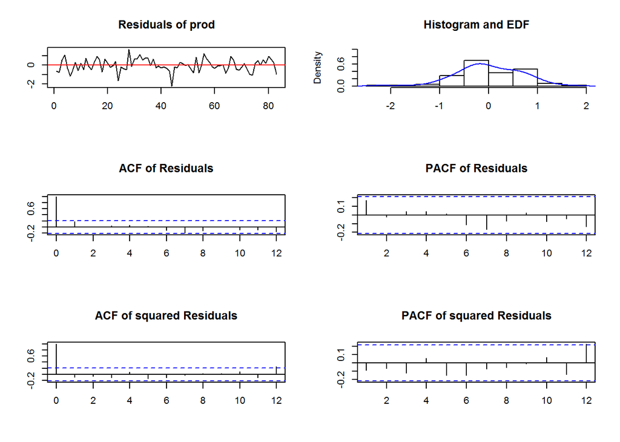

```r
plot(norm1, names = "prod")
```

#### Escenario 2: VAR(2)

```r
### Estimación
p2ct   <- VAR(Canada, p = 2, type = "both")
p2ct
```

```
##
## VAR Estimation Results:
## =======================
##
## Estimated coefficients for equation prod:
## =========================================
## Call:
## prod = prod.l1 + e.l1 + U.l1 + rw.l1 + prod.l2 + e.l2 + U.l2 + rw.l2 + const + trend
##
##     prod.l1        e.l1        U.l1       rw.l1     prod.l2        e.l2
##  1.09880604 -0.14816907 -0.57736715  0.01519072 -0.21942106  0.23300094
##        U.l2       rw.l2       const       trend
##  0.89061470 -0.09343379 -2.16644760  0.06728750
##
##
## Estimated coefficients for equation e:
## ======================================
## Call:
## e = prod.l1 + e.l1 + U.l1 + rw.l1 + prod.l2 + e.l2 + U.l2 + rw.l2 + const + trend
##
##       prod.l1          e.l1          U.l1         rw.l1       prod.l2
##  1.716493e-01  1.635735e+00  2.739686e-01 -6.005622e-02 -9.766366e-02
##          e.l2          U.l2         rw.l2         const         trend
## -4.842222e-01  1.433151e-01  1.689096e-03 -1.509574e+02 -5.706013e-03
##
##
## Estimated coefficients for equation U:
## ======================================
## Call:
## U = prod.l1 + e.l1 + U.l1 + rw.l1 + prod.l2 + e.l2 + U.l2 + rw.l2 + const + trend
##
##      prod.l1         e.l1         U.l1        rw.l1      prod.l2
##  -0.08790304  -0.57610104   0.60018959   0.01181620   0.04320519
##         e.l2         U.l2        rw.l2        const        trend
##   0.38095481  -0.09492249   0.04661948 180.98536416   0.01275563
##
##
## Estimated coefficients for equation rw:
## =======================================
## Call:
## rw = prod.l1 + e.l1 + U.l1 + rw.l1 + prod.l2 + e.l2 + U.l2 + rw.l2 + const + trend
##
##      prod.l1         e.l1         U.l1        rw.l1      prod.l2
##  -0.13327924  -0.24395401  -0.08786974   0.85895095  -0.05272931
##         e.l2         U.l2        rw.l2        const        trend
##   0.21384463  -0.25444874   0.07838534 133.30872014   0.06805925
```

```r
### Diagnóstico
ser22 <- serial.test(p2ct, lags.pt = 16, type = "PT.asymptotic")
ser22$serial
```

```
##
##  Portmanteau Test (asymptotic)
##
## data:  Residuals of VAR object p2ct
## Chi-squared = 209.74, df = 224, p-value = 0.7443
```

```r
arch2 <- arch.test(p2ct, lags.multi = 5)
arch2$arch.mul
```

```
##
##  ARCH (multivariate)
##
## data:  Residuals of VAR object p2ct
## Chi-squared = 528.14, df = 500, p-value = 0.1855
```

```r
norm2 <- normality.test(p2ct)
norm2$jb.mul
```

```
## $JB
##
##  JB-Test (multivariate)
##
## data:  Residuals of VAR object p2ct
## Chi-squared = 2.2882, df = 8, p-value = 0.9709
##
##
## $Skewness
##
##  Skewness only (multivariate)
##
## data:  Residuals of VAR object p2ct
## Chi-squared = 1.2998, df = 4, p-value = 0.8614
##
##
## $Kurtosis
##
##  Kurtosis only (multivariate)
##
## data:  Residuals of VAR object p2ct
## Chi-squared = 0.9884, df = 4, p-value = 0.9115
```

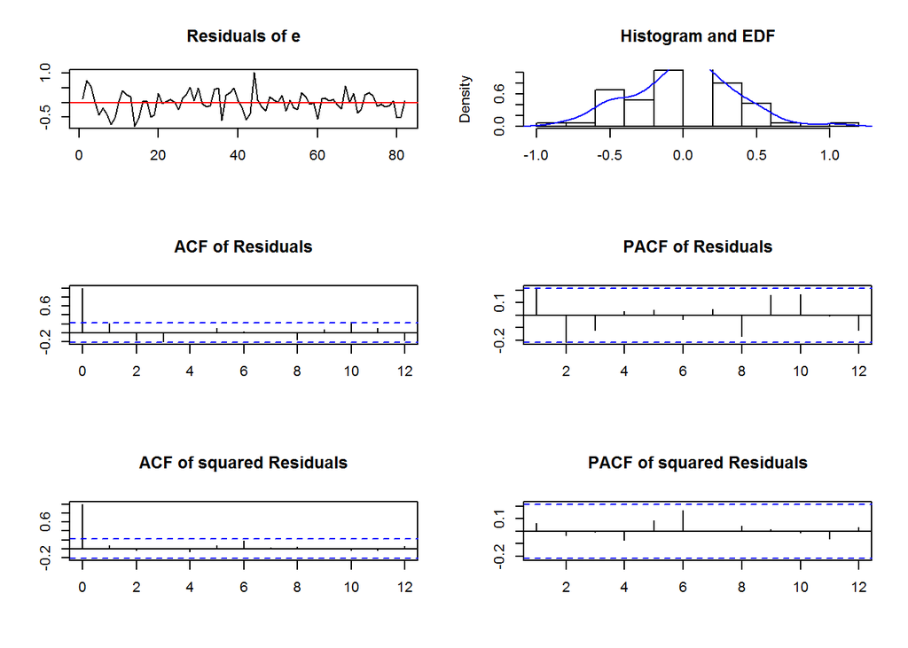

```r
plot(norm2, names = "e")
```

#### Escenario 3: VAR(3)

```r
### Estimación
p3ct   <- VAR(Canada, p = 3, type = "both")
p3ct
```

```
##
## VAR Estimation Results:
## =======================
##
## Estimated coefficients for equation prod:
## =========================================
## Call:
## prod = prod.l1 + e.l1 + U.l1 + rw.l1 + prod.l2 + e.l2 + U.l2 + rw.l2 + prod.l3 + e.l3 + U.l3 + rw.l3 + const + trend
##
##      prod.l1         e.l1         U.l1        rw.l1      prod.l2
##   1.08138761  -0.19622759  -0.75409912  -0.01995026  -0.18078644
##         e.l2         U.l2        rw.l2      prod.l3         e.l3
##  -0.15481450   0.74328605  -0.20123648  -0.02050056   0.45746821
##         U.l3        rw.l3        const        trend
##   0.32217926   0.12123944 -13.21924425   0.07451666
##
##
## Estimated coefficients for equation e:
## ======================================
## Call:
## e = prod.l1 + e.l1 + U.l1 + rw.l1 + prod.l2 + e.l2 + U.l2 + rw.l2 + prod.l3 + e.l3 + U.l3 + rw.l3 + const + trend
##
##       prod.l1          e.l1          U.l1         rw.l1       prod.l2
##    0.18518258    1.76382827    0.12194306   -0.07242428   -0.10936038
##          e.l2          U.l2         rw.l2       prod.l3          e.l3
##   -1.19012450   -0.03229344   -0.02488409    0.02564596    0.61470608
##          U.l3         rw.l3         const         trend
##    0.35975734    0.03172493 -193.37043794   -0.01741357
##
##
## Estimated coefficients for equation U:
## ======================================
## Call:
## U = prod.l1 + e.l1 + U.l1 + rw.l1 + prod.l2 + e.l2 + U.l2 + rw.l2 + prod.l3 + e.l3 + U.l3 + rw.l3 + const + trend
##
##       prod.l1          e.l1          U.l1         rw.l1       prod.l2
##  -0.115838301  -0.630593919   0.633745966   0.002742498   0.092189116
##          e.l2          U.l2         rw.l2       prod.l3          e.l3
##   0.525389579  -0.102428066   0.070509144  -0.028450268  -0.061912900
##          U.l3         rw.l3         const         trend
##   0.045531567  -0.031534562 163.889696250   0.020203832
##
##
## Estimated coefficients for equation rw:
## =======================================
## Call:
## rw = prod.l1 + e.l1 + U.l1 + rw.l1 + prod.l2 + e.l2 + U.l2 + rw.l2 + prod.l3 + e.l3 + U.l3 + rw.l3 + const + trend
##
##      prod.l1         e.l1         U.l1        rw.l1      prod.l2
##  -0.13954289  -0.52468461  -0.10820098   0.86031246  -0.19911318
##         e.l2         U.l2        rw.l2      prod.l3         e.l3
##   0.69673993  -0.38989137  -0.14326894   0.14159721  -0.26039495
##         U.l3        rw.l3        const        trend
##   0.06263254   0.22136045 192.77720875   0.08340852
```

```r
### Diagnóstico
ser33 <- serial.test(p3ct, lags.pt = 16, type = "PT.asymptotic")
ser33$serial
```

```
##
##  Portmanteau Test (asymptotic)
##
## data:  Residuals of VAR object p3ct
## Chi-squared = 173.97, df = 208, p-value = 0.9587
```

```r
arch3 <- arch.test(p3ct, lags.multi = 5)
arch3$arch.mul
```

```
##
##  ARCH (multivariate)
##
## data:  Residuals of VAR object p3ct
## Chi-squared = 512.04, df = 500, p-value = 0.3451
```

```r
norm3 <- normality.test(p3ct)
norm3$jb.mul
```

```
## $JB
##
##  JB-Test (multivariate)
##
## data:  Residuals of VAR object p3ct
## Chi-squared = 9.665, df = 8, p-value = 0.2893
##
##
## $Skewness
##
##  Skewness only (multivariate)
##
## data:  Residuals of VAR object p3ct
## Chi-squared = 4.3714, df = 4, p-value = 0.3581
##
##
## $Kurtosis
##
##  Kurtosis only (multivariate)
##
## data:  Residuals of VAR object p3ct
## Chi-squared = 5.2936, df = 4, p-value = 0.2585
```

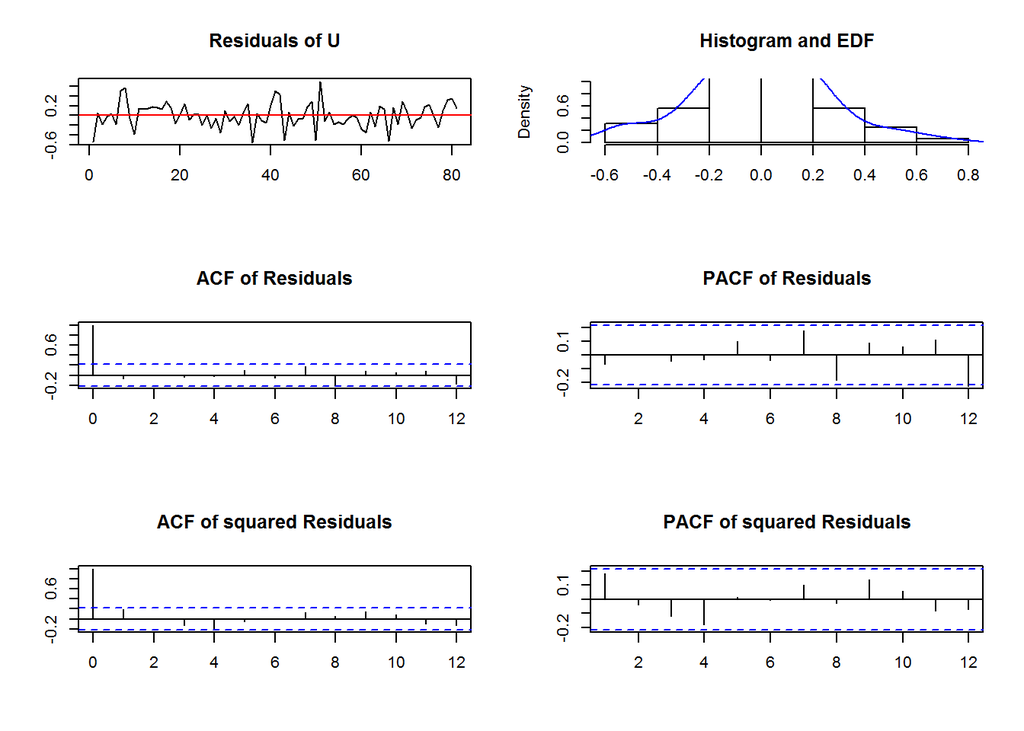

```r
plot(norm3, names = "U")
```

Resumiendo, tenemos los siguientes valores p de los test de diagnóstico:

| Modelo | Portmanteau | ARCH | Normalidad |
| --- | --- | --- | --- |
| $p=3$ | $0.96$ | $0.35$ | $0.29$ |
| $p=2$ | $0.75$ | $0.19$ | $0.97$ |
| $p=1$ | $0.60$ | $0.01$ | $0.27$ |

Dados los test de diagnóstico tenemos que un modelo *VAR(1)* no es viable, luego los modelos *VAR(2)* y *VAR(3)* van a seguir siendo candidatos para el analisis de cointegración.

#### Modelo VEC

Analizando la cointegración entre las variables, planteamos un modelo *VEC* para su ajuste.

```r
### Especificación del modelo

summary(ca.jo(Canada, type = "trace", ecdet = "trend", K = 3,
              spec = "transitory"))
```

```
##
## ######################
## # Johansen-Procedure #
## ######################
##
## Test type: trace statistic , with linear trend in cointegration
##
## Eigenvalues (lambda):
## [1] 4.505013e-01 1.962777e-01 1.676668e-01 4.647108e-02 2.632104e-17
##
## Values of teststatistic and critical values of test:
##
##           test 10pct  5pct  1pct
## r <= 3 |  3.85 10.49 12.25 16.26
## r <= 2 | 18.72 22.76 25.32 30.45
## r <= 1 | 36.42 39.06 42.44 48.45
## r = 0  | 84.92 59.14 62.99 70.05
##
## Eigenvectors, normalised to first column:
## (These are the cointegration relations)
##
##              prod.l1       e.l1       U.l1      rw.l1    trend.l1
## prod.l1   1.00000000  1.0000000  1.0000000  1.0000000   1.0000000
## e.l1     -0.02385143  1.2946681 -2.8831559  4.2418087  -8.2903941
## U.l1      3.16874549  3.4036732 -7.4261514  6.8413561 -12.5578436
## rw.l1     1.83528156 -0.3330945  1.3978789 -0.1393999   2.4466500
## trend.l1 -1.30156097 -0.2302803 -0.5093218 -1.5925918   0.2831079
##
## Weights W:
## (This is the loading matrix)
##
##             prod.l1        e.l1         U.l1        rw.l1      trend.l1
## prod.d -0.006535281 -0.02763446 -0.070975296 -0.014754352  1.077470e-11
## e.d    -0.008503348  0.11414011 -0.008156659  0.003988051  7.400392e-12
## U.d    -0.004718574 -0.06154306  0.020719431 -0.006557248 -4.663936e-12
## rw.d   -0.046213350 -0.14579644 -0.016945105  0.011896044  6.951877e-12
```

```r
summary(ca.jo(Canada, type = "trace", ecdet = "trend", K = 2,
              spec = "transitory"))
```

```
##
## ######################
## # Johansen-Procedure #
## ######################
##
## Test type: trace statistic , with linear trend in cointegration
##
## Eigenvalues (lambda):
## [1] 4.483918e-01 2.323995e-01 1.313250e-01 4.877895e-02 9.508809e-17
##
## Values of teststatistic and critical values of test:
##
##           test 10pct  5pct  1pct
## r <= 3 |  4.10 10.49 12.25 16.26
## r <= 2 | 15.65 22.76 25.32 30.45
## r <= 1 | 37.33 39.06 42.44 48.45
## r = 0  | 86.12 59.14 62.99 70.05
##
## Eigenvectors, normalised to first column:
## (These are the cointegration relations)
##
##             prod.l1        e.l1        U.l1     rw.l1   trend.l1
## prod.l1   1.0000000   1.0000000  1.00000000  1.000000   1.000000
## e.l1      2.7132129  -6.3190324  0.49616472 16.333916 -10.368563
## U.l1      8.8369211 -15.2682881  1.48062661 25.774259 -16.048489
## rw.l1    -0.3716323   3.1817254 -0.04085215 -2.546391   4.927457
## trend.l1 -0.4177976  -0.9335588 -0.26592659 -3.413555  -1.753060
##
## Weights W:
## (This is the loading matrix)
##
##             prod.l1        e.l1        U.l1        rw.l1      trend.l1
## prod.d  0.023155644 -0.02832697 -0.10914770 -0.006295988 -4.784843e-13
## e.d     0.005602438 -0.01739149  0.08679396 -0.001019323 -4.385463e-13
## U.d    -0.019277135  0.01381763 -0.03696147 -0.002276871  4.919851e-13
## rw.d   -0.084618968 -0.02739056 -0.07798404  0.003985020 -1.032563e-13
```

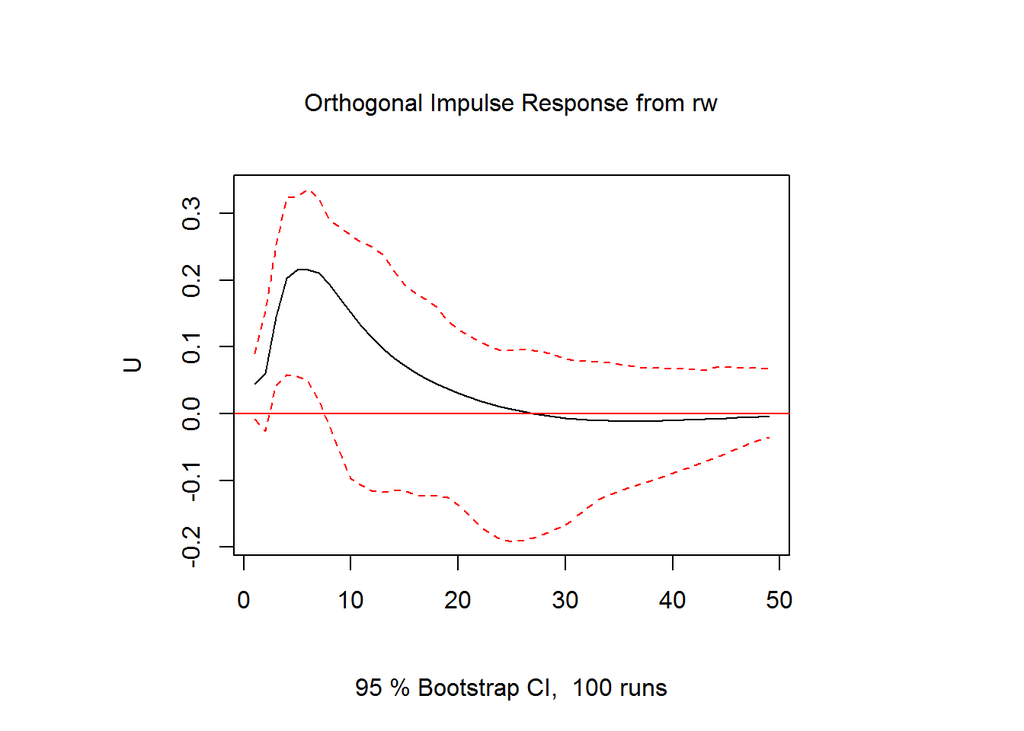

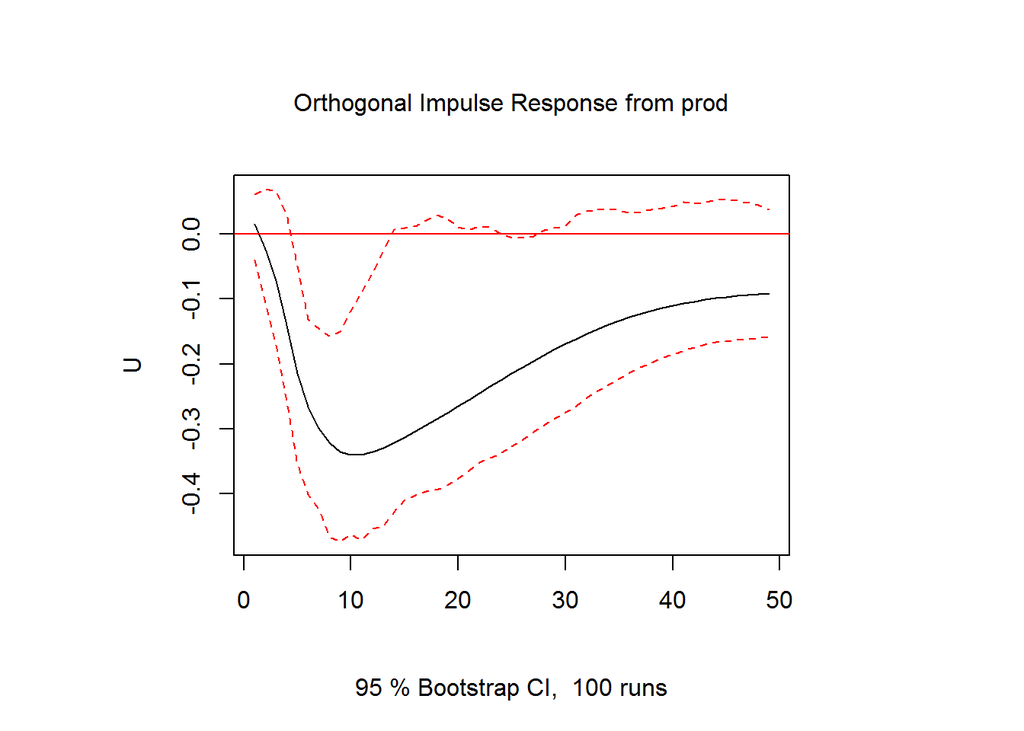

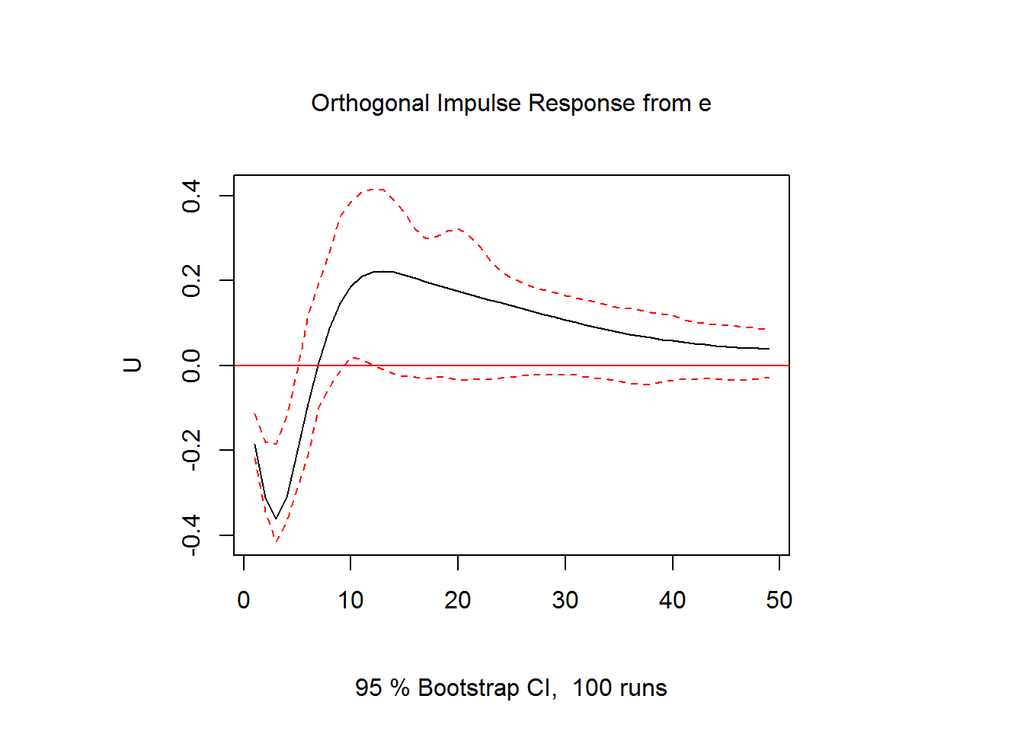

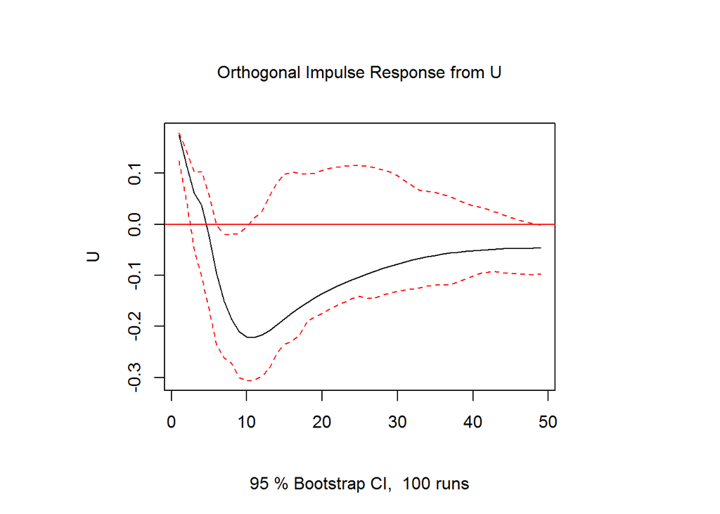

```r
vecm <- ca.jo(Canada[, c("rw", "prod", "e", "U")], type = "trace", ecdet = "none", K = 3, spec = "transitory")

### Funciones de impulso
var.vec <- vec2var(vecm, r = 3)

ir.U <- irf(var.vec, response = "U", n.ahead = 48, boot = TRUE)
plot(ir.U)
```

Una vez analizados las funciones de impulso procedemos a analizar los pronosticos de la descomposición de la varianza respecto al desempleo.

[figure not shown]

```r
fevd.all <- fevd(var.vec, n.ahead = 8)
plot(fevd.all, addbars = 1)
```

```r
fevd.all$U
```

```
##              rw        prod         e          U
## [1,] 0.02917041 0.003946978 0.5114551 0.45542754
## [2,] 0.03106587 0.004271665 0.7239056 0.24075683
## [3,] 0.07804764 0.017132897 0.7661544 0.13866506
## [4,] 0.13608817 0.051198497 0.7152960 0.09741730
## [5,] 0.18043311 0.113135568 0.6286862 0.07774514
## [6,] 0.20948228 0.185302529 0.5289039 0.07631127
## [7,] 0.22204783 0.250474773 0.4396370 0.08784043
## [8,] 0.21915486 0.302484021 0.3737086 0.10465252
```

Por ultimo se realizan los pronosticos del modelo.

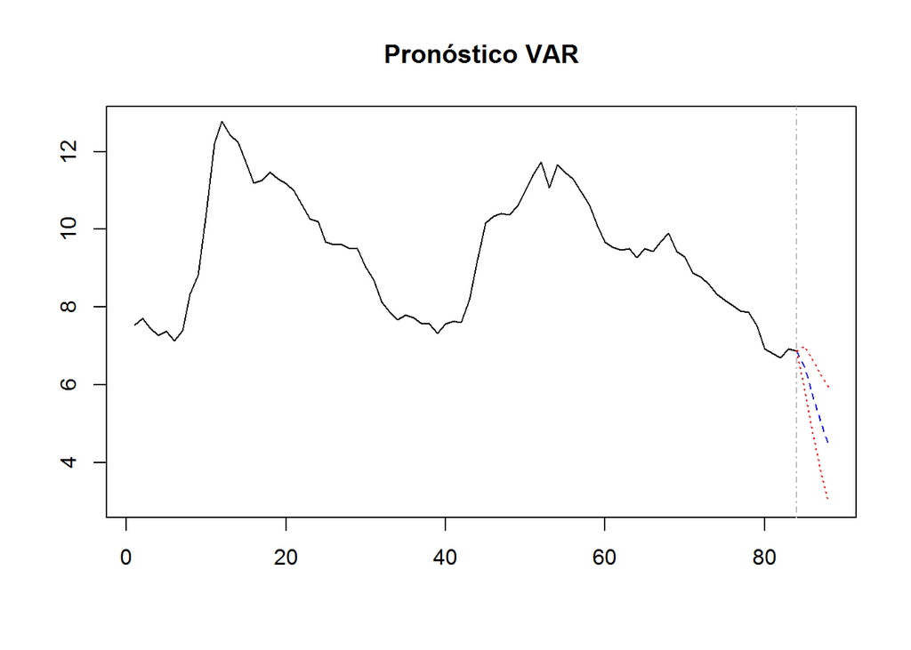

```r
### Comparación de pronósticos
predictions.var <- predict(p3ct, n.ahead = 4, ci = 0.95)
predictions.vec <- predict(var.vec, n.ahead = 4, ci = 0.95)

plot(predictions.var, names = 'U', main = 'Pronóstico VAR')
```

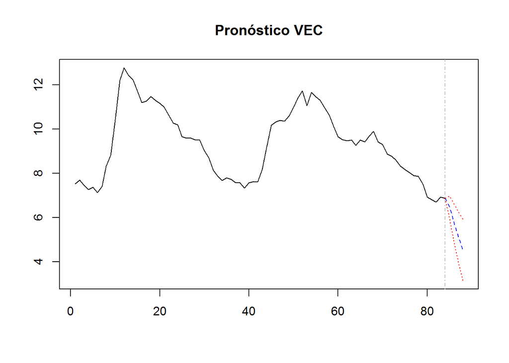

```r
plot(predictions.vec, names = 'U', main = 'Pronóstico VEC')
```

```r
predictions.var$fcst$U
```

```
##          fcst    lower    upper        CI
## [1,] 6.448778 5.901326 6.996230 0.5474518
## [2,] 5.766162 4.864464 6.667860 0.9016979
## [3,] 5.075013 3.847245 6.302781 1.2277682
## [4,] 4.468696 2.983049 5.954342 1.4856465
```

```r
predictions.vec$fcst$U
```

```
##          fcst    lower    upper        CI
## [1,] 6.471903 5.965665 6.978141 0.5062379
## [2,] 5.806998 4.973962 6.640033 0.8330355
## [3,] 5.132390 3.988554 6.276226 1.1438362
## [4,] 4.538630 3.153447 5.923813 1.3851828
```

No se ven diferencias significativas en los pronósticos de los dos modelos. **Se plantea un modelo *SVEC* pero este sale de los alcances del curso.**

```r
SR <- matrix(NA, nrow = 4, ncol = 4)
SR[4, 2] <- 0
LR <- matrix(NA, nrow = 4, ncol = 4)
LR[1, 2:4] <- 0
LR[2:4, 4] <- 0
svec <- SVEC(vecm, LR = LR, SR = SR, r = 1, lrtest = FALSE, boot = TRUE, runs = 100)
summary(svec)
```

```
##
## SVEC Estimation Results:
## ========================
##
## Call:
## SVEC(x = vecm, LR = LR, SR = SR, r = 1, lrtest = FALSE, boot = TRUE,
##     runs = 100)
##
## Type: B-model
## Sample size: 81
## Log Likelihood: -164.179
## Number of iterations: 9
##
## Estimated contemporaneous impact matrix:
##           rw    prod        e        U
## rw    0.1247  0.5515 -0.01982 0.457597
## prod -0.5169  0.1936 -0.27173 0.006354
## e    -0.1434 -0.1503  0.22906 0.122847
## U     0.1269  0.0000 -0.24107 0.037027
##
## Estimated standard errors for impact matrix:
##          rw    prod       e       U
## rw   0.0807 0.18371 0.09435 0.37607
## prod 0.5785 0.09119 0.07837 0.07879
## e    0.1576 0.05171 0.04597 0.12712
## U    0.1362 0.00000 0.03491 0.02823
##
## Estimated long run impact matrix:
##           rw     prod       e U
## rw   -0.9948  0.00000  0.0000 0
## prod -0.2473  0.39378 -0.2426 0
## e    -0.6716 -0.28208  0.3079 0
## U     0.2435  0.05393 -0.2768 0
##
## Estimated standard errors for long-run matrix:
##          rw    prod       e U
## rw   1.0206 0.00000 0.00000 0
## prod 0.3550 0.12243 0.07536 0
## e    0.6984 0.09039 0.06812 0
## U    0.2766 0.03539 0.04814 0
##
## Covariance matrix of reduced form residuals (*100):
##          rw     prod      e        U
## rw   52.946  5.06004 -4.910  3.75503
## prod  5.060 37.85164 -1.644  0.01372
## e    -4.910 -1.64420 11.071 -6.88708
## U     3.755  0.01372 -6.887  7.55949
```

```r
LR[3, 3] <- 0
svec.oi <- update(svec, LR = LR, lrtest = TRUE, boot = FALSE)
svec.oi$LRover
```

```
##
##  LR overidentification
##
## data:  vecm
## Chi^2 = 61.349, df = 1, p-value = 4.774e-15
```

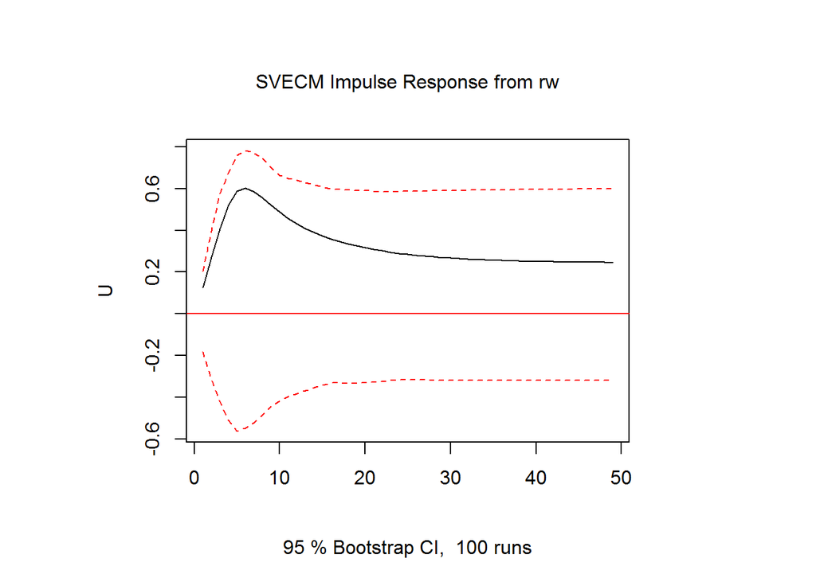

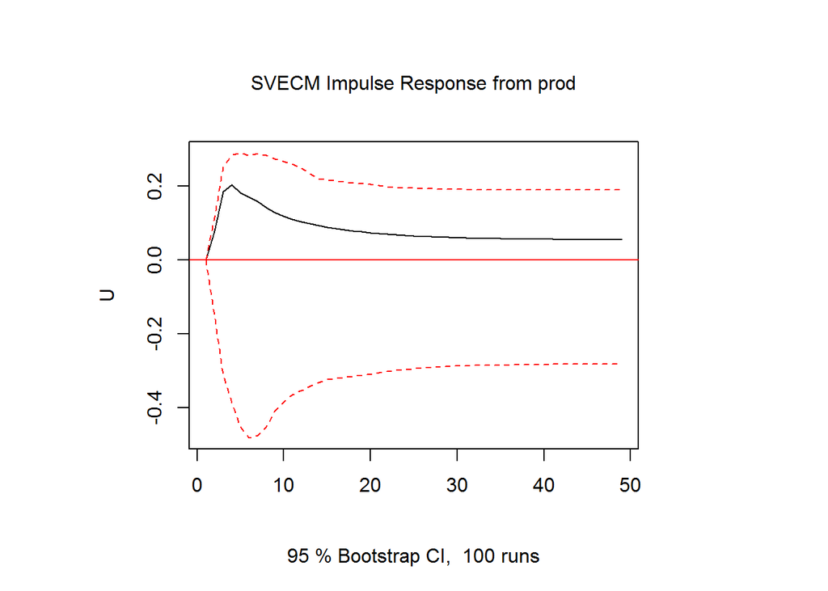

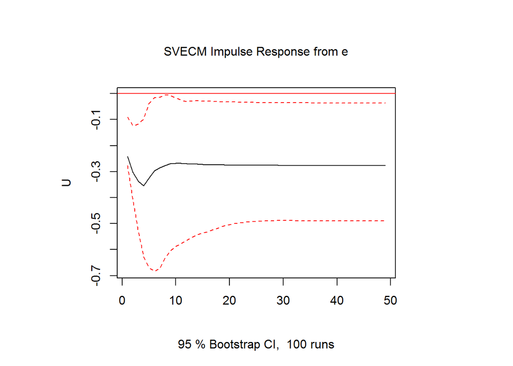

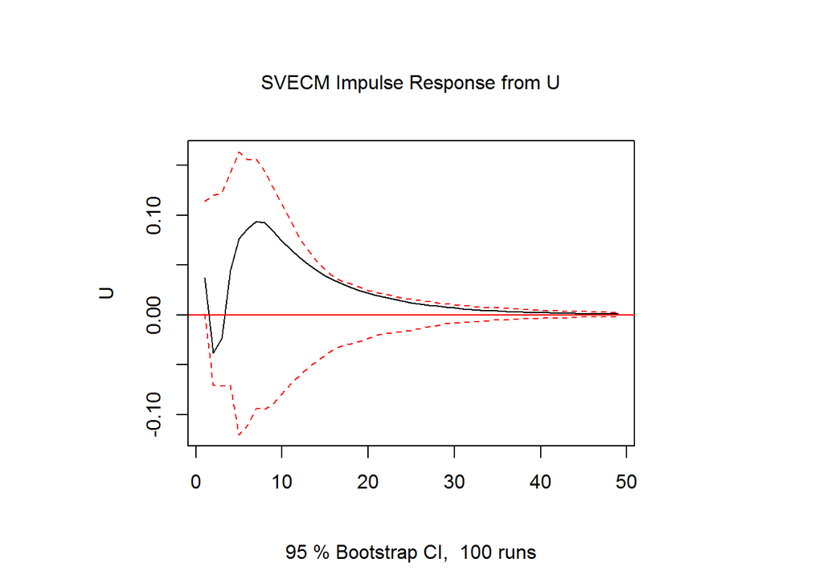

```r
svec.irf <- irf(svec, response = "U", n.ahead = 48, boot = TRUE)
plot(svec.irf)
```

```r
fevd.U <- fevd(svec, n.ahead = 8)$U
fevd.U
```

```
##             rw       prod         e           U
## [1,] 0.2131054 0.00000000 0.7687580 0.018136550
## [2,] 0.3585246 0.02513571 0.6048307 0.011509043
## [3,] 0.4546549 0.07174283 0.4675519 0.006050431
## [4,] 0.5260556 0.08099401 0.3876001 0.005350299
## [5,] 0.5845473 0.07651681 0.3313976 0.007538324
## [6,] 0.6234622 0.07225320 0.2948309 0.009453667
## [7,] 0.6468696 0.06888821 0.2729690 0.011273152
## [8,] 0.6613163 0.06594397 0.2601046 0.012635091
```